# Analysis - Housing Selling Prices

```r
lm2 <- lm(log(SalePrice) ~ TotalSqft, data=train2)
b2 <- coef(lm2)
pander(summary(lm2))
```

|  | Estimate | Std. Error | t value | Pr(>\|t\|) |
| --- | --- | --- | --- | --- |
| **(Intercept)** | 10.98 | 0.01728 | 635.2 | 0 |
| **TotalSqft** | 0.0003171 | 4.983e-06 | 63.64 | 0 |

Fitting linear model: log(SalePrice) ~ TotalSqft

| Observations | Residual Std. Error | $R^2$ | Adjusted $R^2$ |
| --- | --- | --- | --- |
| 1450 | 0.2052 | 0.7366 | 0.7365 |

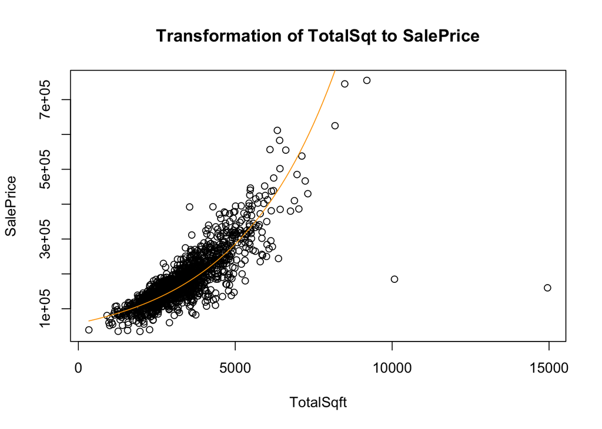

```r
#plot back with original data
plot(SalePrice ~ TotalSqft, data=train)
b <- coef(lm2)
curve(exp(b2[1] + b2[2]*x), add=TRUE, col="orange")
title("Transformation of TotalSqt to SalePrice")
```

The year of the house sold always affect by when the house built or remodel. Therefore I conducted a summary on the `YrSold` and `YearRemodAdd` to find the mean, median, Q1,Q3,Max, and min of the house year built and remodel.  
I found that most of the house sold at 2008 and all the house in the data set has remodel. Average years of house got remodel is at 1985. Therefore, I created a new column `BorRB` to see if the house is remodel before 1985 or not. This is base on the assumption that the newer the house get remodel, the higher the sale price. It’s hard to set a rule on new or old, therefore I used the average years of house got remodel, which is 1985 year.

```r
summary(train$YrSold)
```

```
##    Min. 1st Qu.  Median    Mean 3rd Qu.    Max.
##    2006    2007    2008    2008    2009    2010
```

```r
#all these houses sold at a mean year 2008.

sum(is.na(train$YearRemodAdd))
```

```
## [1] 0
```

```r
#all house has Remodel

summary(train$YearRemodAdd)
```

```
##    Min. 1st Qu.  Median    Mean 3rd Qu.    Max.
##    1950    1967    1994    1985    2004    2010
```

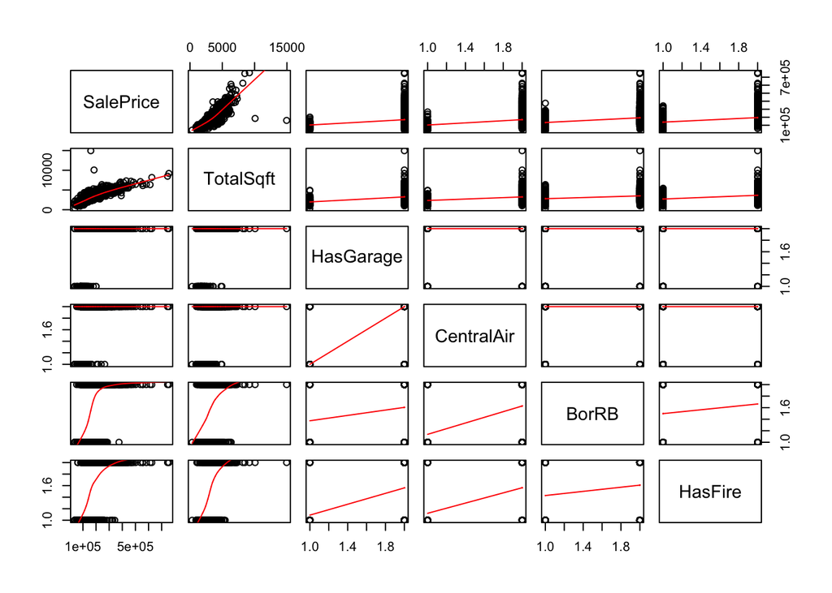

```r
#mean 1985

#remodel above the average.
#suppose the neweer the house or remodel, the better the selling price.
#So we will usee the mean as aa cut off point.
train <- train %>% mutate(BorRB = as.factor(ifelse(YearRemodAdd >= 1985, "Yes", "No")))

pairs(train[,c("SalePrice", "TotalSqft", "HasGarage", "CentralAir", "BorRB", "HasFire")], panel=panel.smooth)
```

```r
#remove the outliner from the above part
train2 <- train[-c(524,1299), ]


lm3 <- lm(log(SalePrice) ~ TotalSqft + HasGarage + CentralAir  + HasFire + TotalSqft:BorRB, data = train2)
pander(summary(lm3))
```

|  | Estimate | Std. Error | t value | Pr(>\|t\|) |
| --- | --- | --- | --- | --- |
| **(Intercept)** | 10.86 | 0.02452 | 443 | 0 |
| **TotalSqft** | 0.0002075 | 5.979e-06 | 34.71 | 1.833e-192 |
| **HasGarageYes** | 0.1154 | 0.0204 | 5.658 | 1.842e-08 |
| **CentralAirY** | 0.2055 | 0.01874 | 10.96 | 6.305e-27 |
| **HasFireYes** | 0.09169 | 0.01011 | 9.072 | 3.723e-19 |
| **TotalSqft:BorRBYes** | 6.003e-05 | 2.951e-06 | 20.35 | 4.082e-81 |

Fitting linear model: log(SalePrice) ~ TotalSqft + HasGarage + CentralAir + HasFire + TotalSqft:BorRB

| Observations | Residual Std. Error | $R^2$ | Adjusted $R^2$ |
| --- | --- | --- | --- |
| 1450 | 0.1669 | 0.8262 | 0.8256 |

All the variable are significant and the adjusted $R^2$ is 82.56%.

#### Graphing the model:

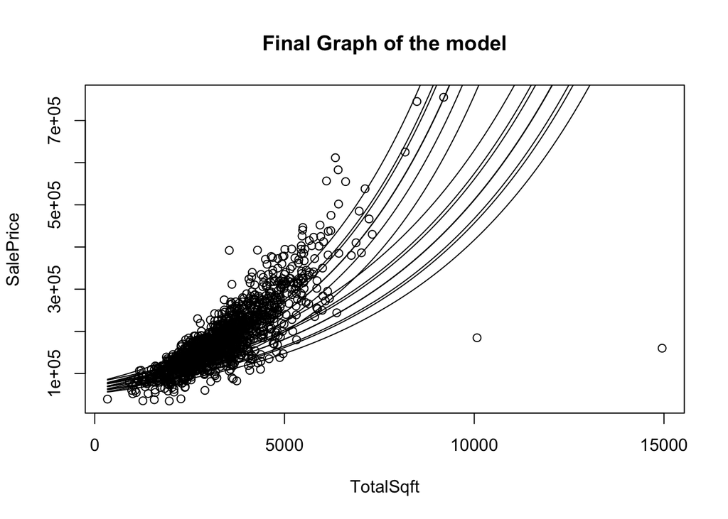

```r
b <- coef(lm3)
#baase line
plot(SalePrice ~ TotalSqft, data=train)
#      3  4  5 6         6 only change the slope, not intercept, which is the x term
# [1] "No.N.No.No"    "Yes.N.No.No"   "No.Y.No.No"    "Yes.Y.No.No"   "No.N.Yes.No"   "Yes.N.Yes.No"
# [7] "No.Y.Yes.No"   "Yes.Y.Yes.No"  "No.N.No.Yes"   "Yes.N.No.Yes"  "No.Y.No.Yes"   "Yes.Y.No.Yes"
# [13] "Yes.N.Yes.Yes" "No.Y.Yes.Yes"  "Yes.Y.Yes.Yes"

curve(exp(b[1] + b[2]*x), add=TRUE) #N.N.N.N
#
curve(exp((b[1]+b[3])+(b[2])*x) ,add = TRUE) #"Yes.N.No.No"
#
curve(exp((b[1]+b[4])+(b[2])*x) ,add = TRUE) #"No.Y.No.No"
#
curve(exp((b[1]+b[3]+b[4])+(b[2])*x),add = TRUE) #"Yes.Y.No.No"
#
curve(exp((b[1]+b[5])+(b[2])*x) ,add = TRUE) #"No.N.Yes.No"
#
curve(exp((b[1]+b[3]+b[5])+(b[2])*x) ,add = TRUE) #"Yes.N.Yes.No"
#
curve(exp((b[1]+b[4]+b[5])+(b[2])*x) ,add = TRUE) #"No.Y.Yes.No"
#
curve(exp((b[1]+b[3]+b[4]+b[5])+(b[2])*x) ,add = TRUE) #"Yes.Y.Yes.No"
#
curve(exp((b[1])+(b[2]+b[6])*x) ,add = TRUE) #"No.N.No.Yes"
#
curve(exp((b[1]+b[3])+(b[2]+b[6])*x) ,add = TRUE) #"Yes.N.No.Yes"
#
curve(exp((b[1]+b[4])+(b[2]+b[6])*x) ,add = TRUE) #"No.Y.No.Yes"
#
curve(exp((b[1]+b[3]+b[4])+(b[2]+b[6])*x) ,add = TRUE) #"Yes.Y.No.Yes"
#
curve(exp((b[1]+b[3]+b[5])+(b[2]+b[6])*x) ,add = TRUE) #"Yes.N.Yes.Yes"
#
curve(exp((b[1]+b[4]+b[5])+(b[2]+b[6])*x) ,add = TRUE) #"No.Y.Yes.Yes"
#
curve(exp((b[1]+b[3]+b[4]+b[5])+(b[2]+b[6])*x) ,add = TRUE) #"Yes.Y.Yes.Yes"
title("Final Graph of the model")
```

#### Checking the assumption:

1. The regression relation between Y and X is linear.
2. The error terms are normally distributed with E{ϵi}=0.
3. The variance of the error terms is constant over all X values.
4. The X values can be considered fixed and measured without error.
5. The error terms are independent.

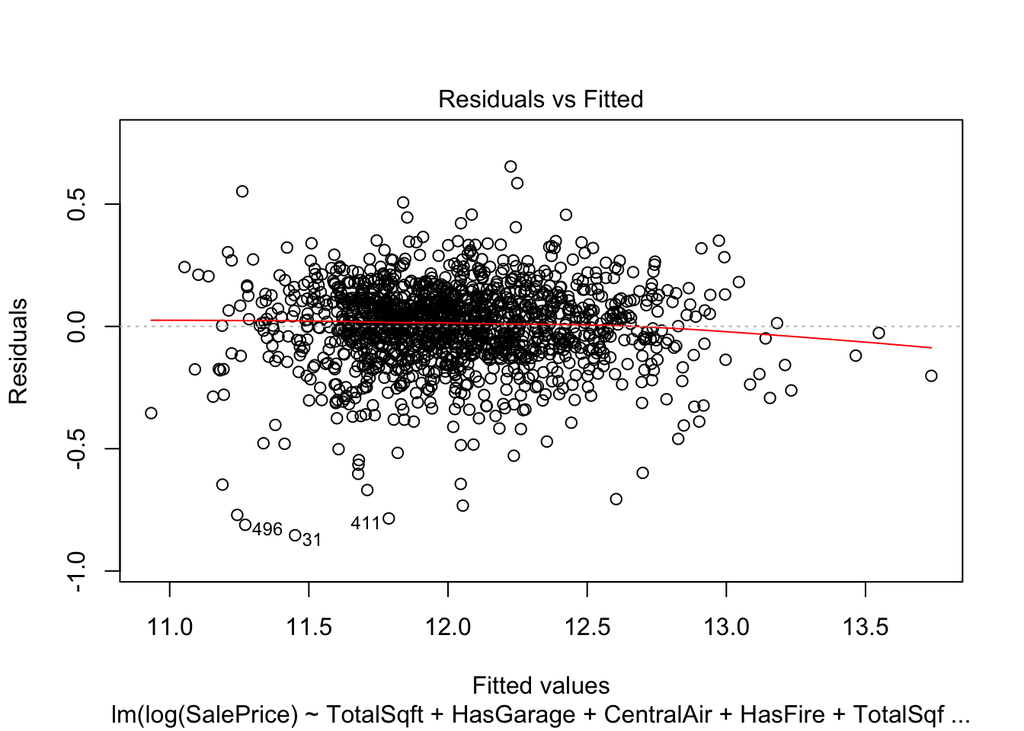

```r
plot(lm3, which = 1)
```

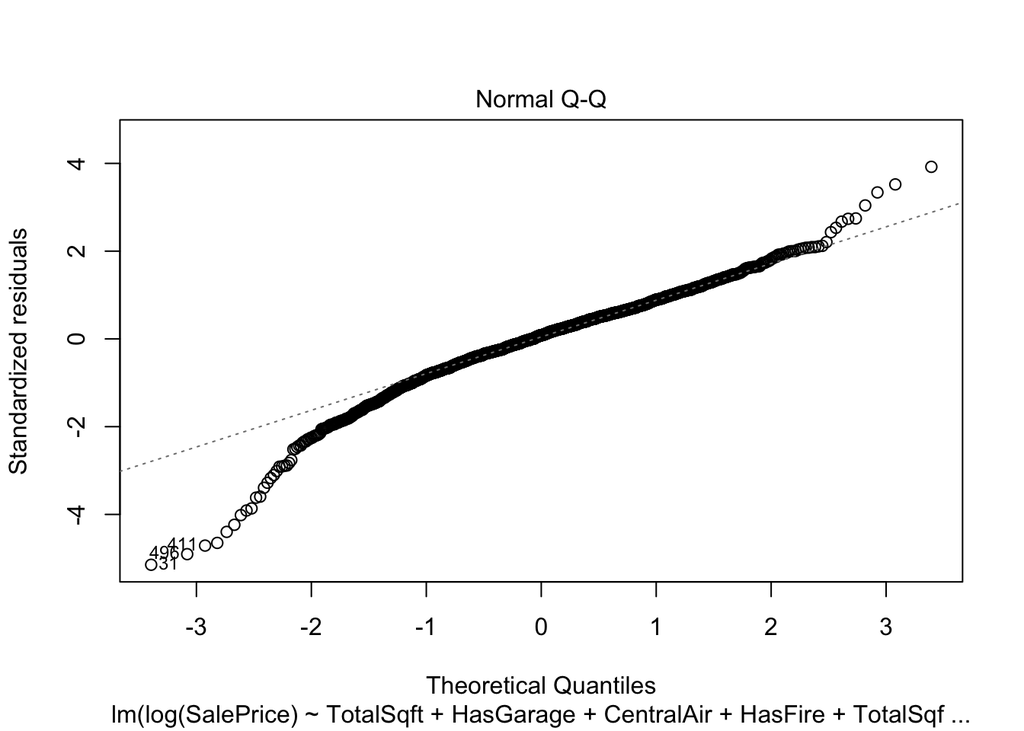

```r
plot(lm3, which = 2)
```

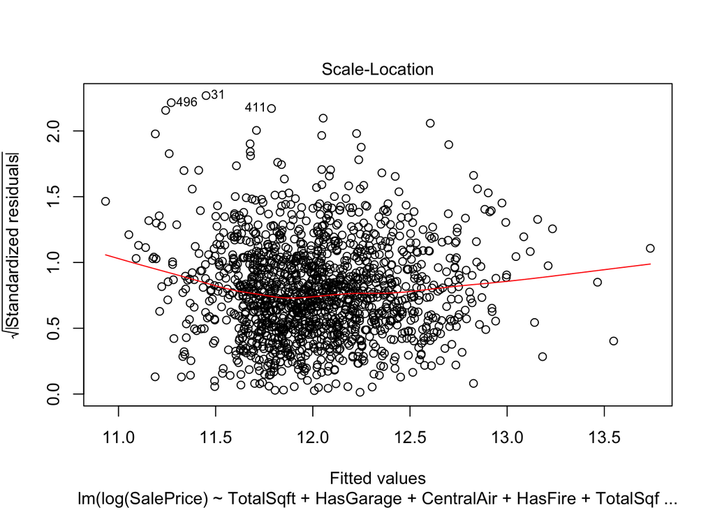

```r
plot(lm3, which = 3)
```

The Assumption 2 may not be really valid since there is a heavy tail on the normal Q-Q plot, but everything look fine. We will go to validation in the below.

## Model Validation

```r
nrow(train)
```

```
## [1] 1460
```

```r
set.seed(121)
keep <- sample(1:nrow(train), 1000)
mytrain <- train[keep,]
mytest <- train[-keep,]

mytrain_lm <- mytrain[-c(524,1299),]

## Okay to filter when running the lm...
which(rownames(mytrain) %in% c(411,633,917))
```

```
## [1]  84 743
```

```r
lm_train <- lm(log(SalePrice) ~ TotalSqft + HasGarage + CentralAir  + HasFire + TotalSqft:BorRB, data =mytrain[-c(174,264,300),])
summary(lm_train)
```

```
##
## Call:
## lm(formula = log(SalePrice) ~ TotalSqft + HasGarage + CentralAir +
##     HasFire + TotalSqft:BorRB, data = mytrain[-c(174, 264, 300),
##     ])
##
## Residuals:
##      Min       1Q   Median       3Q      Max
## -1.74516 -0.08449  0.01517  0.10749  0.48937
##
## Coefficients:
##                     Estimate Std. Error t value Pr(>|t|)
## (Intercept)        1.088e+01  3.186e-02 341.585  < 2e-16 ***
## TotalSqft          1.948e-04  7.713e-06  25.262  < 2e-16 ***
## HasGarageYes       1.453e-01  2.668e-02   5.445 6.53e-08 ***
## CentralAirY        1.869e-01  2.444e-02   7.647 4.86e-14 ***
## HasFireYes         1.136e-01  1.336e-02   8.502  < 2e-16 ***
## TotalSqft:BorRBYes 5.762e-05  3.924e-06  14.682  < 2e-16 ***
## ---
## Signif. codes:  0 '***' 0.001 '**' 0.01 '*' 0.05 '.' 0.1 ' ' 1
##
## Residual standard error: 0.1806 on 986 degrees of freedom
##   (5 observations deleted due to missingness)
## Multiple R-squared:  0.8055, Adjusted R-squared:  0.8045
## F-statistic: 816.8 on 5 and 986 DF,  p-value: < 2.2e-16
```

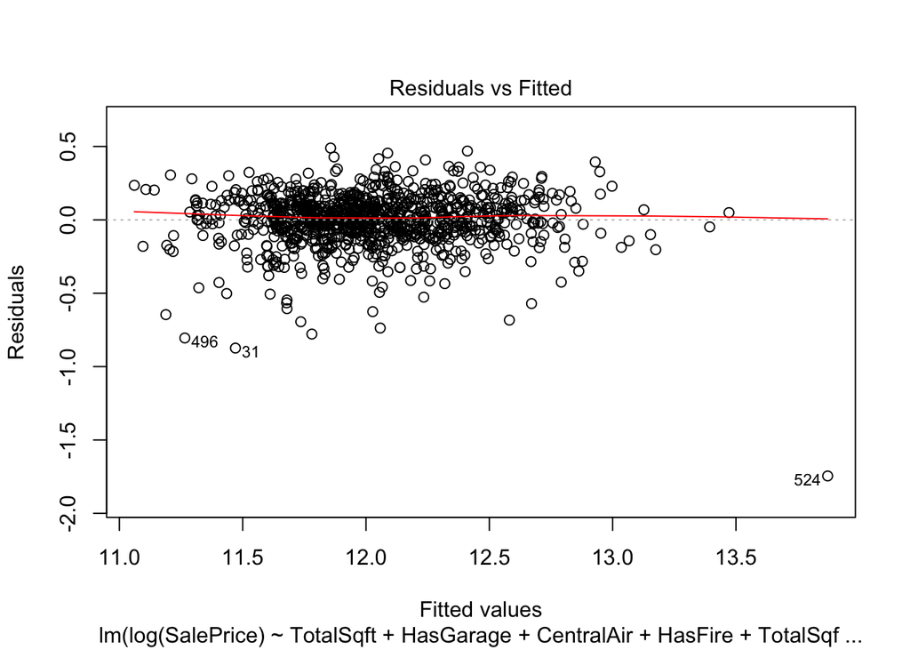

```r
plot(lm_train, which=1)
```

```r
### Impute missing values
apply(mytest[,c("TotalSqft","HasGarage","CentralAir","HasFire")], 2, function(x) sum(is.na(x)))
```

```
##  TotalSqft  HasGarage CentralAir    HasFire
##          3          0          0          0
```

```r
mytest$TotalSqft = ifelse(is.na(mytest$TotalSqft),
                     ave(mytest$TotalSqft, FUN = function(x) mean(x, na.rm = TRUE)),
                     mytest$TotalSqft)


#Validation
yhat <- predict(lm_train, newdata=mytest)
sum(is.na(yhat))
```

```
## [1] 0
```

```r
Y <- log(mytest$SalePrice) #make sure Y is on the same scale that you used in your lm

SSTO <- sum( (Y - mean(Y))^2 )
SSE <- sum( (Y - yhat)^2 )
n <- nrow(mytest)
p <- length(coef(lm_train))
adjr2 <- 1 - (n-1)/(n-p)*SSE/SSTO
summary(lm_train)$adj.r.squared
```

```
## [1] 0.8045303
```

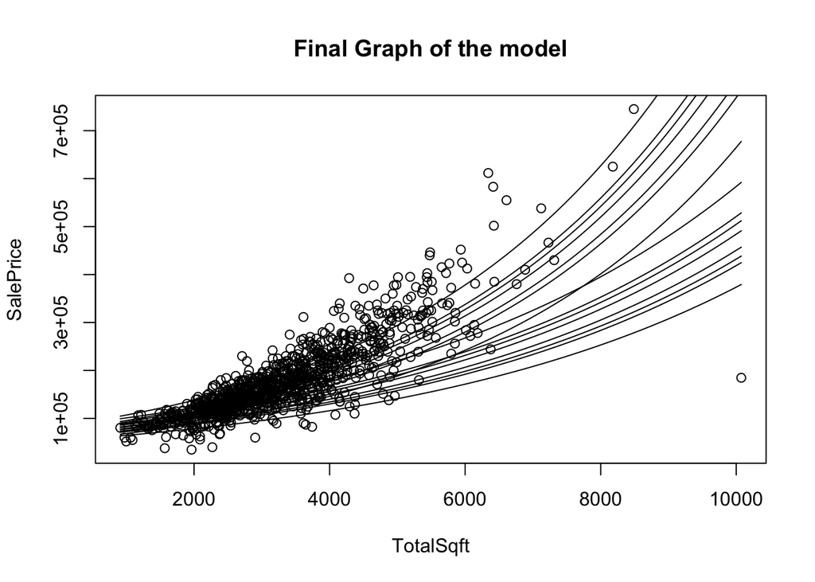

```r
## Draw it
b <- coef(lm_train)

#baase line
plot(SalePrice ~ TotalSqft, data=mytrain)
#      3  4  5 6         6 only change the slope, not intercept, which is the x term
# [1] "No.N.No.No"    "Yes.N.No.No"   "No.Y.No.No"    "Yes.Y.No.No"   "No.N.Yes.No"   "Yes.N.Yes.No"
# [7] "No.Y.Yes.No"   "Yes.Y.Yes.No"  "No.N.No.Yes"   "Yes.N.No.Yes"  "No.Y.No.Yes"   "Yes.Y.No.Yes"
# [13] "Yes.N.Yes.Yes" "No.Y.Yes.Yes"  "Yes.Y.Yes.Yes"

curve(exp(b[1] + b[2]*x), add=TRUE) #N.N.N.N
#
curve(exp((b[1]+b[3])+(b[2])*x) ,add = TRUE) #"Yes.N.No.No"
#
curve(exp((b[1]+b[4])+(b[2])*x) ,add = TRUE) #"No.Y.No.No"
#
curve(exp((b[1]+b[3]+b[4])+(b[2])*x),add = TRUE) #"Yes.Y.No.No"
#
curve(exp((b[1]+b[5])+(b[2])*x) ,add = TRUE) #"No.N.Yes.No"
#
curve(exp((b[1]+b[3]+b[5])+(b[2])*x) ,add = TRUE) #"Yes.N.Yes.No"
#
curve(exp((b[1]+b[4]+b[5])+(b[2])*x) ,add = TRUE) #"No.Y.Yes.No"
#
curve(exp((b[1]+b[3]+b[4]+b[5])+(b[2])*x) ,add = TRUE) #"Yes.Y.Yes.No"
#
curve(exp((b[1])+(b[2]+b[6])*x) ,add = TRUE) #"No.N.No.Yes"
#
curve(exp((b[1]+b[3])+(b[2]+b[6])*x) ,add = TRUE) #"Yes.N.No.Yes"
#
curve(exp((b[1]+b[4])+(b[2]+b[6])*x) ,add = TRUE) #"No.Y.No.Yes"
#
curve(exp((b[1]+b[3]+b[4])+(b[2]+b[6])*x) ,add = TRUE) #"Yes.Y.No.Yes"
#
curve(exp((b[1]+b[3]+b[5])+(b[2]+b[6])*x) ,add = TRUE) #"Yes.N.Yes.Yes"
#
curve(exp((b[1]+b[4]+b[5])+(b[2]+b[6])*x) ,add = TRUE) #"No.Y.Yes.Yes"
#
curve(exp((b[1]+b[3]+b[4]+b[5])+(b[2]+b[6])*x) ,add = TRUE) #"Yes.Y.Yes.Yes"
title("Final Graph of the model")
```

## Interpretation

For: `curve(exp((b[1]+b[3])+(b[2])*x) ,add = TRUE) #"Yes.N.No.No"`  
The y-intercept, which is the base price for the housing has a garage increase by 15.6%. The slope remain the same, which means that there are 1.968% increase in SalePrice for every addition 100 square feet increase in TotalSqft.

For `curve(exp((b[1]+b[4])+(b[2])*x) ,add = TRUE) #"No.Y.No.No"`  
The y-intercept, which is the base price for the housing has a central air system increase by 20.5%. The slope remain the same, which means that there are 1.968% increase in SalePrice for every addition 100 square feet increase in TotalSqft.

For `curve(exp((b[1]+b[3]+b[4])+(b[2])*x),add = TRUE) #"Yes.Y.No.No"`  
The y-intercept, which is the base price for the housing has a central air system and garage increase by 39.3%. The slope remain the same, which means that there are 1.968% increase in SalePrice for every addition 100 square feet increase in TotalSqft.

For `curve(exp((b[1]+b[5])+(b[2])*x) ,add = TRUE) #"No.N.Yes.No"`  
The y-intercept, which is the base price for the housing has a fire place increase by 12%. The slope remain the same, which means that there are 1.968% increase in SalePrice for every addition 100 square feet increase in TotalSqft.

For `curve(exp((b[1]+b[3]+b[5])+(b[2])*x) ,add = TRUE) #"Yes.N.Yes.No"`  
The y-intercept, which is the base price for the housing has a fire place and garage increase by 29.5%. The slope remain the same, which means that there are 1.968% increase in SalePrice for every addition 100 square feet increase in TotalSqft.

For `curve(exp((b[1]+b[4]+b[5])+(b[2])*x) ,add = TRUE) #"No.Y.Yes.No"`  
The y-intercept, which is the base price for the housing has a central air system and fire place increase by 35%. The slope remain the same, which means that there are 1.968% increase in SalePrice for every addition 100 square feet increase in TotalSqft.

For `curve(exp((b[1]+b[3]+b[4]+b[5])+(b[2])*x) ,add = TRUE) #"Yes.Y.Yes.No"`  
The y-intercept, which is the base price for the housing has a central air system, garage, and fire place increase by 56.2%. The slope remain the same, which means that there are 1.968% increase in SalePrice for every addition 100 square feet increase in TotalSqft.